# 2주차 패키지과제 제출 주혜인

2021 3 16

### chapter1

#### 문제0.기본세팅

```r
pacman::p_load("tidyverse","data.table","VIM")
setwd("C:/Users/JU HYE IN/Desktop/피셋/패키지과제/2주차패키지")
data<-fread("data.csv",header=TRUE, stringsAsFactors = FALSE)
```

#### 문제1. ’2’로 끝나는 변수 제거

```r
data<-data %>% select(-ends_with("2"))
```

#### 문제2. VIM패키지 이용하여 시각화 한 후 간단히 해석

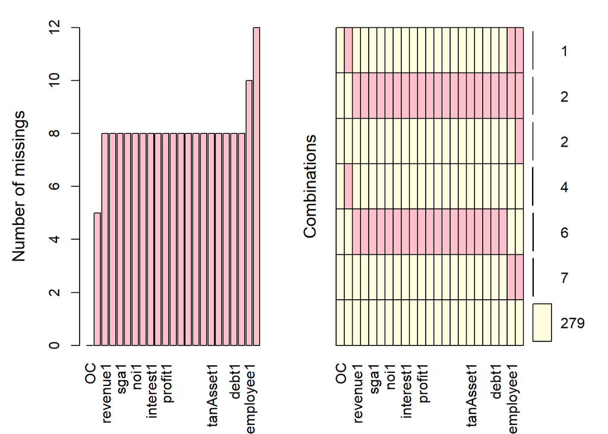

```r
data %>% aggr(prop=FALSE, col=c("lightyellow","pink"), numbers=TRUE)
```

#### 문제 3-1 숫자데이터의 NA값을 mean imputation을 통해 채우세요

```r
means<-data %>%
  select_if(is.numeric) %>%
  lapply(mean,na.rm=TRUE)

nums<-colnames(data %>%
                 select_if(is.numeric))

data[,nums]<-data %>%
  select_if(is.numeric) %>%
  replace_na(replace=means)
```

#### 문제 3-2 범주 데이터의 NA값을 mode imputation을 통해 채우세요.

```r
ca<-data %>%
  select_if(is.character) %>%
  colnames

mode_values<-data %>%
  select_if(is.character) %>%
  lapply(function(x){
    uniq<-unique(x)
    table(uniq)
    return(uniq[which.max(tabulate(match(x,uniq)))])
  })

data[,ca]<-data%>%
  select_if(is.character) %>%
  replace_na(replace = mode_values)

data %>% is.na %>% colSums##imputation완료##
```

```
##              OC        bedCount        revenue1      salescost1            sga1
##               0               0               0               0               0
##         salary1            noi1            noe1       interest1           ctax1
##               0               0               0               0               0
##         profit1    liquidAsset1     quickAsset1    receivableS1 inventoryAsset1
##               0               0               0               0               0
##      nonCAsset1       tanAsset1     OnonCAsset1    receivableL1           debt1
##               0               0               0               0               0
##        surplus1       employee1     ownerChange
##               0               0               0
```

#### 문제 4.“OC”를 타겟 변수를 사용하기 위해 “open”=1, “close”=0으로 바꾸세요

```r
data$OC<- if_else(data$OC=="open", 1, 0)
```

#### 문제5.숫자 데이터 중 integer 자료형인 경우 num자료형으로 바꾸세요.

```r
data[,1:22] <- lapply(data[,1:22],as.numeric)
str(data)
```

```
## Classes 'data.table' and 'data.frame':   301 obs. of  23 variables:
##  $ OC             : num  1 1 1 1 1 1 1 1 1 1 ...
##  $ bedCount       : num  175 410 468 353 196 243 213 250 280 55 ...
##  $ revenue1       : num  4.22e+09 1.29e+10 1.00e+09 7.25e+10 4.90e+10 ...
##  $ salescost1     : num  0.00 2.01e+09 5.15e+08 0.00 0.00 ...
##  $ sga1           : num  3.96e+09 1.03e+10 4.47e+08 7.07e+10 4.77e+10 ...
##  $ salary1        : num  2.03e+09 5.65e+09 2.96e+08 3.18e+10 2.45e+10 ...
##  $ noi1           : num  1.57e+07 2.70e+08 7.62e+04 5.06e+08 1.12e+08 ...
##  $ noe1           : num  1.52e+07 5.12e+08 3.00e+04 1.26e+09 1.42e+09 ...
##  $ interest1      : num  1.32e+07 1.87e+08 0.00 1.20e+09 1.31e+09 ...
##  $ ctax1          : num  3.16e+07 7.85e+07 0.00 1.74e+08 0.00 ...
##  $ profit1        : num  2.25e+08 2.10e+08 4.19e+07 9.03e+08 8.07e+07 ...
##  $ liquidAsset1   : num  1.01e+09 3.54e+09 2.72e+08 1.30e+10 6.32e+09 ...
##  $ quickAsset1    : num  9.98e+08 3.41e+09 2.54e+08 1.15e+10 5.87e+09 ...
##  $ receivableS1   : num  4.70e+08 6.98e+08 8.10e+06 0.00 4.10e+09 ...
##  $ inventoryAsset1: num  1.50e+07 1.15e+08 1.88e+07 1.51e+09 4.44e+08 ...
##  $ nonCAsset1     : num  2.51e+09 1.14e+10 1.20e+08 4.32e+10 4.37e+10 ...
##  $ tanAsset1      : num  2.36e+09 1.05e+10 1.20e+08 3.83e+10 4.33e+10 ...
##  $ OnonCAsset1    : num  1.43e+08 3.41e+08 0.00 3.95e+09 2.22e+08 ...
##  $ receivableL1   : num  0 251680 0 0 0 ...
##  $ debt1          : num  6.83e+08 8.77e+09 9.24e+07 4.24e+10 4.99e+10 ...
##  $ surplus1       : num  1.50e+09 1.27e+09 0.00 8.64e+09 9.03e+09 ...
##  $ employee1      : num  62 801 234 663 206 397 221 489 243 370 ...
##  $ ownerChange    : chr  "same" "same" "same" "same" ...
##  - attr(*, ".internal.selfref")=<externalptr>
```

일부 변수의 자료형이 str()을 사용하여 구조를 확인했을때 interger64로 나타났지만, is.numeric의 결과값은 true로 나왔습니다. character변수는 마지막 열 한 개 뿐이어서 앞의 1:22까지의 열 전체를 다시한번 is.numeric함수를 통해 형변환을 하였더니 그 후에는 str함수를 써도 전부 numeric으로 잘 나왔습니다.

### chapter2

```r
library(caret)
set.seed(1234)
```

### [모델1 로지스틱 회귀]

#### 문제1. 앞서 전처리한 데이터를 createDataPartition으로 7:3으로 train과 validation set으로 나누세요.

```r
ind<-createDataPartition(data$OC, p=0.3, list=F)
tr_data<-data[-ind,]
valid_data<-data[ind,]
```

#### 문제2. train 데이터의 모든 변수를 이용하여 ’OC’를 타겟으로 하는 로지스틱 회귀를 만들고 validation set의 accuracy값을 구하세요.

```r
fit1=glm(OC~., data=tr_data, family = binomial)
prob<-predict(fit1, valid_data, type="response")
yhat=ifelse(prob>0.5, 1, 0)
table(yhat, valid_data$OC)
```

```
##
## yhat  0  1
##    0  0  2
##    1  6 83
```

```r
#Accuracy
sum(yhat==valid_data$OC)/nrow(valid_data)
```

```
## [1] 0.9120879
```

#### 문제3. 단계적선택법을 이용하여 변수를 선택하고, 선택된 변수들로 로지스틱 회귀를 만들어 validation set의 Accuracy값을 구하세요.

```r
fit2=step(fit1, direction = "both")
```

```
## Start:  AIC=74.95
## OC ~ bedCount + revenue1 + salescost1 + sga1 + salary1 + noi1 +
##     noe1 + interest1 + ctax1 + profit1 + liquidAsset1 + quickAsset1 +
##     receivableS1 + inventoryAsset1 + nonCAsset1 + tanAsset1 +
##     OnonCAsset1 + receivableL1 + debt1 + surplus1 + employee1 +
##     ownerChange
##
##                   Df Deviance    AIC
## - ctax1            1   28.953 72.953
## - salescost1       1   28.953 72.953
## - revenue1         1   28.953 72.953
## - sga1             1   28.953 72.953
## - profit1          1   28.953 72.953
## - noi1             1   28.953 72.953
## - noe1             1   28.953 72.953
## - debt1            1   28.956 72.956
## - surplus1         1   28.993 72.993
## - employee1        1   29.027 73.027
## - OnonCAsset1      1   29.059 73.059
## - bedCount         1   29.280 73.280
## - salary1          1   29.482 73.482
## - liquidAsset1     1   29.696 73.696
## - quickAsset1      1   29.779 73.779
## - inventoryAsset1  1   30.373 74.373
## - tanAsset1        1   30.777 74.777
## - nonCAsset1       1   30.791 74.791
## - interest1        1   30.834 74.834
## - receivableL1     1   30.848 74.848
## <none>                 28.953 74.953
## - ownerChange      1   31.231 75.231
## - receivableS1     1   32.724 76.724
##
## Step:  AIC=72.95
## OC ~ bedCount + revenue1 + salescost1 + sga1 + salary1 + noi1 +
##     noe1 + interest1 + profit1 + liquidAsset1 + quickAsset1 +
##     receivableS1 + inventoryAsset1 + nonCAsset1 + tanAsset1 +
##     OnonCAsset1 + receivableL1 + debt1 + surplus1 + employee1 +
##     ownerChange
##
##                   Df Deviance    AIC
```

[output cut: 341 more lines]

```
## + inventoryAsset1  1   33.288 57.288
## + noe1             1   33.503 57.503
## + liquidAsset1     1   33.639 57.639
## + surplus1         1   33.648 57.648
## + salary1          1   33.730 57.730
## + ctax1            1   33.750 57.750
## + OnonCAsset1      1   33.778 57.778
## - noi1             1   37.849 57.849
## - receivableS1     1   41.989 61.989
## - salescost1       1   43.897 63.897
## - tanAsset1        1   44.764 64.764
## - nonCAsset1       1   44.912 64.912
## - receivableL1     1   45.647 65.647
## - quickAsset1      1   46.898 66.898
## - revenue1         1   47.877 67.877
```

```r
formula(fit2)
```

```
## OC ~ revenue1 + salescost1 + noi1 + interest1 + quickAsset1 +
##     receivableS1 + nonCAsset1 + tanAsset1 + receivableL1 + ownerChange
```

```r
reduced_fit=glm(OC ~ revenue1 + salescost1 + noi1 + interest1 + quickAsset1 +
    receivableS1 + nonCAsset1 + tanAsset1 + receivableL1 + ownerChange, data=tr_data, family = binomial)
summary(reduced_fit)
```

```
##
## Call:
## glm(formula = OC ~ revenue1 + salescost1 + noi1 + interest1 +
##     quickAsset1 + receivableS1 + nonCAsset1 + tanAsset1 + receivableL1 +
##     ownerChange, family = binomial, data = tr_data)
##
## Deviance Residuals:
##      Min        1Q    Median        3Q       Max
## -2.62555   0.00016   0.02839   0.14686   1.39850
##
## Coefficients:
##                   Estimate Std. Error z value Pr(>|z|)
## (Intercept)      2.162e+00  9.377e-01   2.305  0.02114 *
## revenue1         6.986e-10  2.796e-10   2.498  0.01248 *
## salescost1      -1.151e-09  4.074e-10  -2.825  0.00473 **
## noi1            -2.777e-09  1.038e-09  -2.676  0.00746 **
## interest1       -5.215e-09  3.245e-09  -1.607  0.10807
## quickAsset1     -1.034e-09  3.596e-10  -2.876  0.00403 **
## receivableS1    -1.456e-09  5.804e-10  -2.509  0.01210 *
## nonCAsset1       1.662e-08  6.892e-09   2.411  0.01589 *
## tanAsset1       -1.658e-08  6.888e-09  -2.407  0.01606 *
## receivableL1    -1.888e-06  3.343e-05  -0.056  0.95497
## ownerChangesame  2.167e+00  1.316e+00   1.646  0.09968 .
## ---
## Signif. codes:  0 '***' 0.001 '**' 0.01 '*' 0.05 '.' 0.1 ' ' 1
##
## (Dispersion parameter for binomial family taken to be 1)
##
##     Null deviance: 74.307  on 209  degrees of freedom
## Residual deviance: 33.778  on 199  degrees of freedom
## AIC: 55.778
##
## Number of Fisher Scoring iterations: 15
```

```r
prob2<-predict(reduced_fit, valid_data, type="response")
yhat2=ifelse(prob2>0.5, 1, 0)
table(yhat2, valid_data$OC)
```

```
##
## yhat2  0  1
##     1  6 85
```

```r
#Accuracy
sum(yhat2==valid_data$OC)/length(yhat2)
```

```
## [1] 0.9340659
```

### [모델2 랜덤포레스트]

#### 문제4. 그리드서치를 위해 expand.grid를 이용하여 다음과 같은 데이터 프레임을 만드세요.

```r
acc_rf=expand.grid(mtry=c(3,4,5), acc=NA);acc_rf
```

```
##   mtry acc
## 1    3  NA
## 2    4  NA
## 3    5  NA
```

#### 문제5. 로지스틱회귀에서 선택된 변수들로 랜덤포래스트에 대한 5-fold CV 그리드서치를 진행하여 acc_rf의 acc변수에 해당 Accuracy값을 넣으세요.

```r
library(randomForest)
tr_data$ownerChange<-as.factor(tr_data$ownerChange)
cvstat<-numeric(3)
for (i in 1:3){
  for (j in 1:5){
    f<-createFolds(tr_data$OC, k=5)#리스트
    ind<-f[[j]]
    cv.test=tr_data[ind,]
    cv.train=tr_data[-ind,]
    rf=randomForest(OC ~ revenue1 + salescost1 + noi1 + interest1 + quickAsset1 +receivableS1 + nonCAsset1 + tanAsset1 + receivableL1 + ownerChange, data=cv.train,ntree=10, mtry=acc_rf[i,1])
    rf_prob=predict(rf,cv.test)
    yhat=ifelse(rf_prob>0.5, 1,0)
    table(yhat,cv.test$OC)
    cvstat[j]<-sum(yhat==cv.test$OC)/nrow(cv.test)
  }
  acc_rf$acc[i]<-mean(cvstat)
}
acc_rf
```

```
##   mtry       acc
## 1    3 0.9571429
## 2    4 0.9476190
## 3    5 0.9619048
```

#### 문제6. acc_rf에서 가장 높은 Accuracy값의 행을 출력하세요.

```r
acc_rf[which.max(acc_rf$acc),]
```

```
##   mtry       acc
## 3    5 0.9619048
```

#### 문제7. 가장 좋은 파라미터 조합으로 랜덤포레스트 모델을 학습시킨 후, varImpPlot과 ggplot을 이용해 다음과 같이 시각화 하여 모델을 사용해주세요.pink

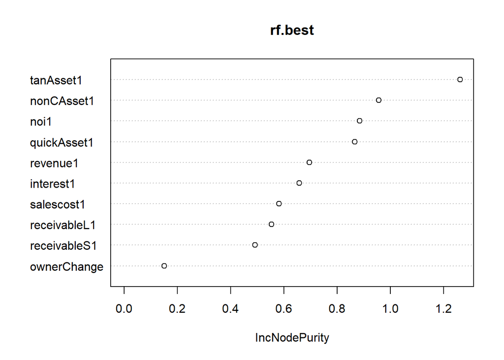

```r
rf.best=randomForest(OC ~ revenue1 + salescost1 + noi1 + interest1 + quickAsset1 +receivableS1 + nonCAsset1 + tanAsset1 + receivableL1 + ownerChange, data=tr_data,ntree=10, mtry=5, importance=TRUE)

imp<-varImpPlot(rf.best, type=2)
```

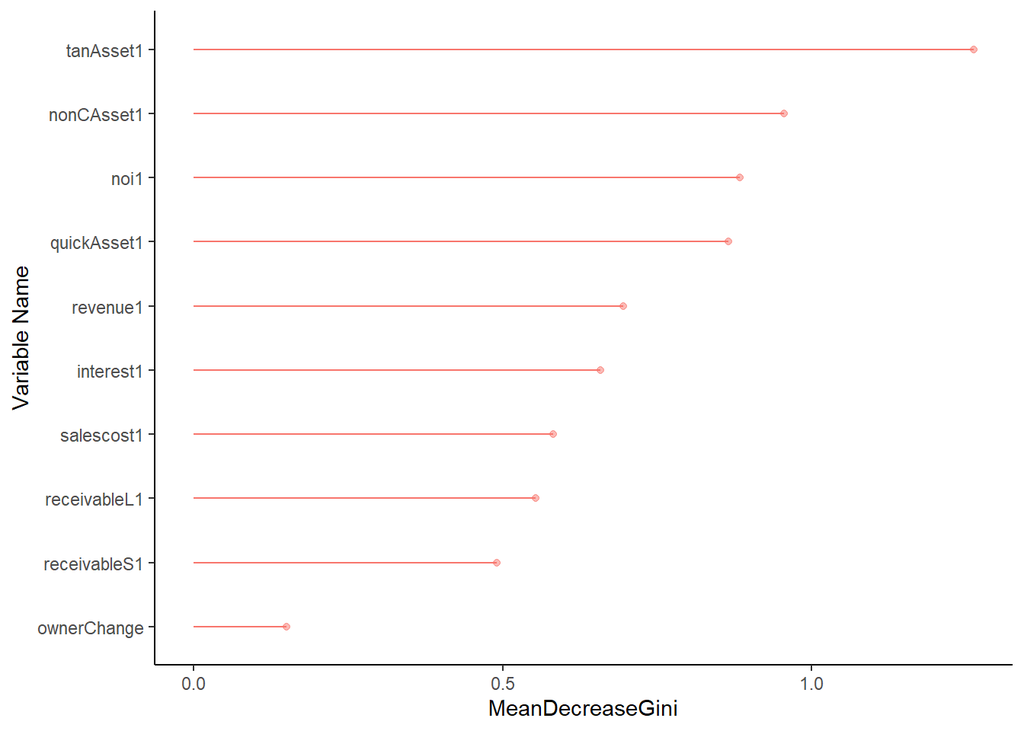

```r
imp<-as.data.frame(imp)
imp$var_names<-rownames(imp)
ggplot(imp, aes(x=reorder(var_names, IncNodePurity), y=IncNodePurity, color="pink")) +
  geom_point(alpha=0.5) +
  geom_segment(aes(x=var_names,xend=var_names,y=0,yend=IncNodePurity)) +
  ylab("MeanDecreaseGini") +
  xlab("Variable Name") +
  theme_classic()+
  theme(legend.position = "none") +
  coord_flip()
```

### chapter3

```r
pacman::p_load("MASS","MLmetrics","caret","randomForest")
set.seed(1234)
```

### 문제1.

```r
bdata<-Boston
ind<-createDataPartition(bdata$medv, p=0.2, list=F)
test<-bdata[ind,]
train<-bdata[-ind,]
```

### 문제2.

```r
RMSE_rf<-expand.grid(mtry=c(3,4,5), ntree=c(10,100,200), RMSE=NA);RMSE_rf
```

```
##   mtry ntree RMSE
## 1    3    10   NA
## 2    4    10   NA
## 3    5    10   NA
## 4    3   100   NA
## 5    4   100   NA
## 6    5   100   NA
## 7    3   200   NA
## 8    4   200   NA
## 9    5   200   NA
```

### 문제3.medv를 종속변수로 하는 랜덤포레스트에 대한 5-fold cv 그리드서치를 진행하여 RMSE_rf의 RMSE변수에 해당 RMSE값을 넣으세요. (이중 for문을 이용하여 직접 코드를 짤 것)

```r
cvstat=numeric(5)
for (i in 1:9){
  for (j in 1:5){
    f<-createFolds(train$medv, k=5)#리스트
    ind<-f[[j]]
    cv.train=train[-ind,]
    cv.test=train[ind,]
    rf=randomForest(medv~., data=cv.train,ntree=RMSE_rf[i,2], mtry=RMSE_rf[i,1])
    yhat=predict(rf,cv.test)
    cvstat[j]<-RMSE(yhat, cv.test$medv)
  }
  RMSE_rf$RMSE[i]<-mean(cvstat)
}

RMSE_rf
```

```
##   mtry ntree     RMSE
## 1    3    10 3.192357
## 2    4    10 4.006231
## 3    5    10 3.349909
## 4    3   100 3.552465
## 5    4   100 4.199874
## 6    5   100 3.518738
## 7    3   200 3.525836
## 8    4   200 3.017643
## 9    5   200 3.381702
```

### 문제4 RMSE_rf에서 가장 낮은 RMSE값을 가진 행을 출력하세요

```r
RMSE_rf[which.min(RMSE_rf$RMSE),]
```

```
##   mtry ntree     RMSE
## 8    4   200 3.017643
```

```r
best_fit=randomForest(medv~., data=train,ntree=100, mtry=5)
yhat=predict(best_fit, test)
RMSE(yhat, test$medv)
```

```
## [1] 4.496193
```